# Study location

Flooding for the Pilot Action experiment took place in the Colusa Basin on 5,435 acres owned by Reclamation District 108 (RD 108) near Knights Landing, CA. Sampling was conducted in the RD108 canal system immediately before canal water was pumped into the Sacramento River at the Rough and Ready pumping facility (approximately river mile 100), and in the River up- and downstream of the pump discharge location (Fig.1).

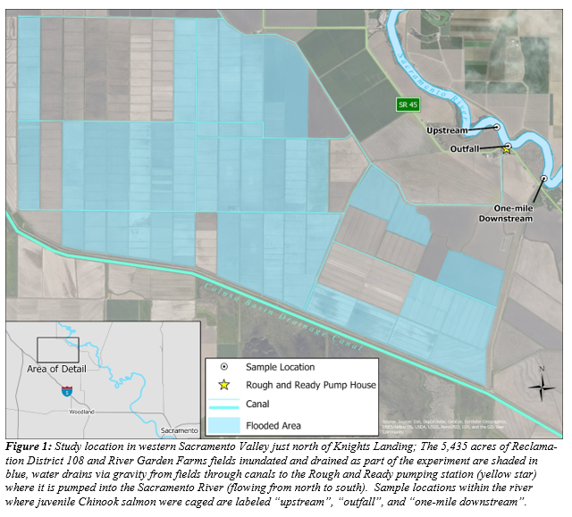

# Water management

Starting on December 15, 2018, 7,175 acre-feet of water was used to flood the 5,435 participating managed floodplain acres. Flood-up was completed by January 15, 2019. Drainage began February 8, 2019 and ended March 8, 2019. Approximately one-quarter of the flooded acreage was drained each week. The Rough and Ready pumping facility can operate over a broad range of export discharge rates between 80-955cfs. For baseline conditions, a single 80cfs pump can be used. For higher discharge rates the facility has five 175cfs pumps which can be run individually or together in various combinations.

# Sampling dates and locations

Site locations (Fig. 1, Table 1) included the drainage canal at the export pumps (RRCAN), in the Sacramento River upstream of the pump discharge (RRSAC1), two locations in the Sacramento River at the pump outfall (RRSAC2A and RRSAC2B), in the Sacramento River a half mile downstream of the export pumps (RRSAC3), and in the Sacramento River one mile downstream of the pumps (RRSAC4). Two cage locations were selected at the pump outfall site in the Sacramento River in order to protect against damaged or lost cages at a location that 1) is a popular public fishing spot where potential vandalism was a concern, 2) is located on an outside bend in the river prone to debris accumulation, and 3) where a turbulent upstream eddy forms when the pumps are discharging making tethering cages particularly challenging. The second location (RRSAC2B), immediately upstream of the export pumps and within the upstream eddy and protected from view and from debris by riparian vegetation, was added to create redundancy and alleviate some of these concerns.

Table 1: Sample location codes and descriptions

| Site Code | Site Description | Start Date | Number of Samples |
| --- | --- | --- | --- |
| RRSAC1 | river, upstream | 11/13/2018 | 19 |
| RRSAC2A | river, outfall (exposed) | 1/8/2019 | 18 |
| RRSAC2B | river, outfall (protected) | 2/12/2019 | 9 |
| RRSAC3 | river, downstream 0.5 miles | 2/5/2019 | 10 |
| RRSAC4 | river, downstream 1.0 miles | 2/5/2019 | 10 |
| RRCAN | floodplain drainage canal | 11/13/2018 | 19 |

# Water quality and zooplankton sampling

At each sample location, water quality data was collected with a YSI Exo2 multi-parameter sonde. Water quality parameters collected were: temperature (degrees C), dissolved oxygen (mg/L), turbidity (NTU), chlorophyl-a fluorescence (µg/L), blue-green algae fluorescence (µg/L), electrical conductivity (µg/cm), salinity (PSU), and pH. Onset HOBO dissolved oxygen and temperature data loggers were deployed at all locations collecting continuous data at 15-minute intervals.

All sites were sampled for zooplankton diversity and abundance using net tows. In the river, a 30-cm diameter x 150 µm mesh zooplankton net fitted with a flowmeter was thrown five meters and retrieved through the water column four times orthogonal to water flow, accounting for drift. Flow meter data was recorded to quantify the volume of water sampled. In the canal site where water stage fluctuations occasionally limit the use of a larger net, a 15-cm diameter x 150 µm mesh zooplankton net was thrown five meters and retrieved through the water column four times. Shallow-water nets cannot be fitted with a flowmeter and the volume of water sampled can be determined by the area of the mouth of the net multiplied by the distance towed (π*.075^2*20 ~ 0.35m^3). All zooplankton samples were preserved in 95% ethanol. Zooplankton were identified to the lowest taxonomic level possible and counted using a dissecting microscope at 8x magnification. Dry carbon biomass conversions either taken from the literature (Dumont 1975) or measured empirically by the Kimmerer Laboratory at San Francisco State's Romber Tiburon Center were applied to zooplankton species counts to estimate zooplaknton biomass.

# Fish growth

Two or three enclosures were deployed at each site (two each at RRSAC2A and RRSAC2B and three everywhere else), each containing 10 PIT-tagged Feather River hatchery-origin juvenile Chinook salmon. Fish enclosures were built with 1-inch PVC, measured 4-feet wide by 4-feet long by 2-feet deep, and encased in ¼-inch black plastic square mesh with a re-sealable access door on the top panel. Fish enclosures were equipped with four bullet-shaped crab floats and tethered to shore. Each week, fish were caught out of their enclosures, scanned for PIT identification, measured for fork length in millimeters, and weighed for mass in grams on an OHAUS Scout Pro portable electronic balance with 0.01g precision. If there was fish mortality, "placebo fish" were added to an enclosure to maintain fish density at 10 fish per enclosure. placebo fish were of identical origin to enclosure fish and were maintained at the UC Davis Center for Aquatic Biology and Aquaculture for the duration of the Pilot Action.